# Lab 4: Hypothesis Testing for One Proportion / Mean

Gabriel Etrata and Theo Kaufman

April 4, 2016

#### Introductory Test: Time Perception

How accurately do people perceive time?

```r
length(times)
```

```
## [1] 48
```

```r
mean(times)
```

```
## [1] 13.70833
```

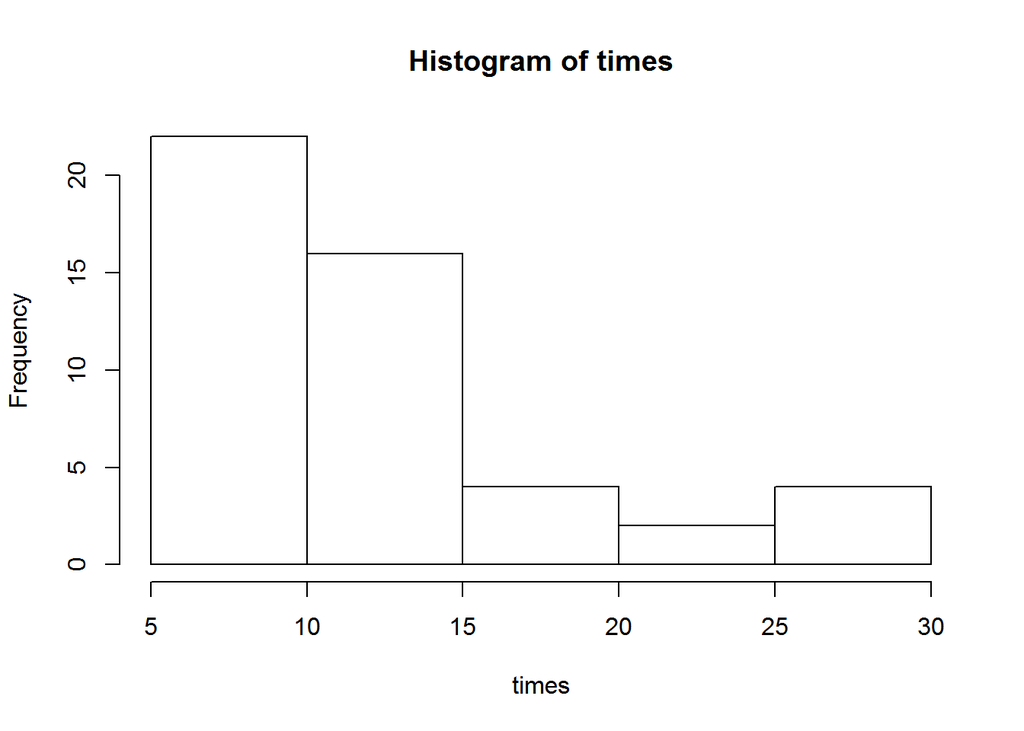

```r
hist(times)
```

The histogram is right-skewed and unimodal.

Null hypothesis: In the population, the average perceived time will equal the true length of the snippet.

$H_o: \mu = 10$

Alternative hypothesis: In the population, people will tend to overestimate the length of the song snippet.

$H_a: \mu > 10$

```r
faketimes <- times - 3.71
mean(faketimes)
```

```
## [1] 9.998333
```

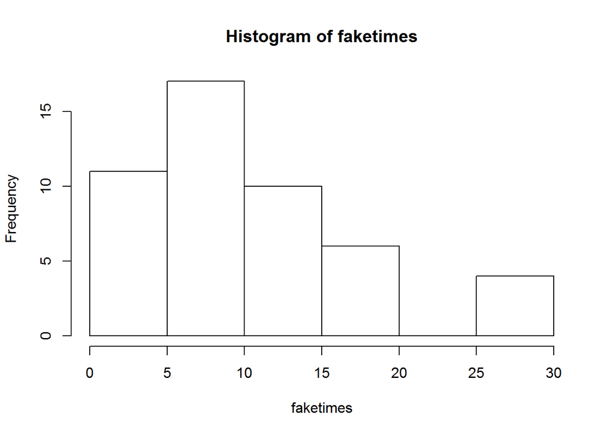

```r
hist(faketimes)
```

```r
sample1 <- sample(faketimes, 48, replace = T)
mean(sample1)
```

```
## [1] 9.8525
```

```r
set.seed(5)
samplemeans <- replicate (1000, mean(sample(faketimes, 48, replace = T)))
#sort(samplemeans)
```

I found it particuarly interesting that it is highly unlikely to accurately perceive time without thinking about it. I think that the study could’ve been tested among various types of music. I sometimes find that it’s easier to keep focus with instrumental music, as opposed to music with vocals. Does it have anything to do with the genre of music? Is there anything that can be done to improve our subconscious time keeping, or is exceedingly difficult to keep track of time with our minds?

#### Coke vs. Pepsi

1. Do BHSEC college students reflect the US population’s preference for Coke to Pepsi?

```r
table(soda)
```

```
## soda
##  Coke Pepsi
##    20    18
```

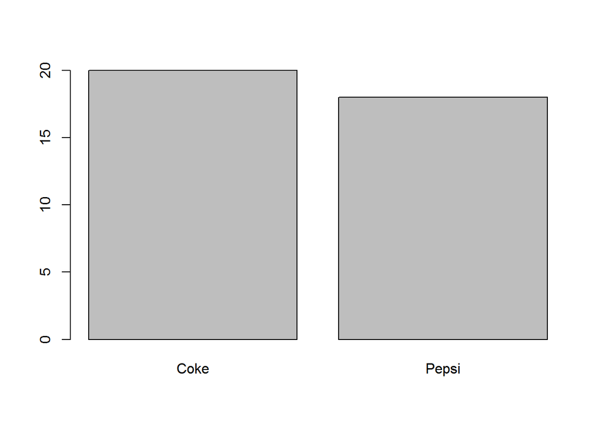

```r
barplot(soda)
```

```r
20/38
```

```
## [1] 0.5263158
```

$\hat{p} = 0.53$

Null hypothesis: The BHSEC population reflects the US population’s preference for Coke to Pepsi. $H_o: p = 0.66$

```r
sodaSimulation <- sample(3, 38, replace = T)
table(sodaSimulation)
```

```
## sodaSimulation
##  1  2  3
## 11  8 19
```

If Coke is represented by 2 and 3, then 27/38 (71%) preferred Coke.

```r
set.seed(1000)
randomization.test(soda, null = (2/3), num = 1000, distribution = T)
```

```
## One categorical variable
## Observed Proportion: 0.526
## Randomizing, please wait...
```

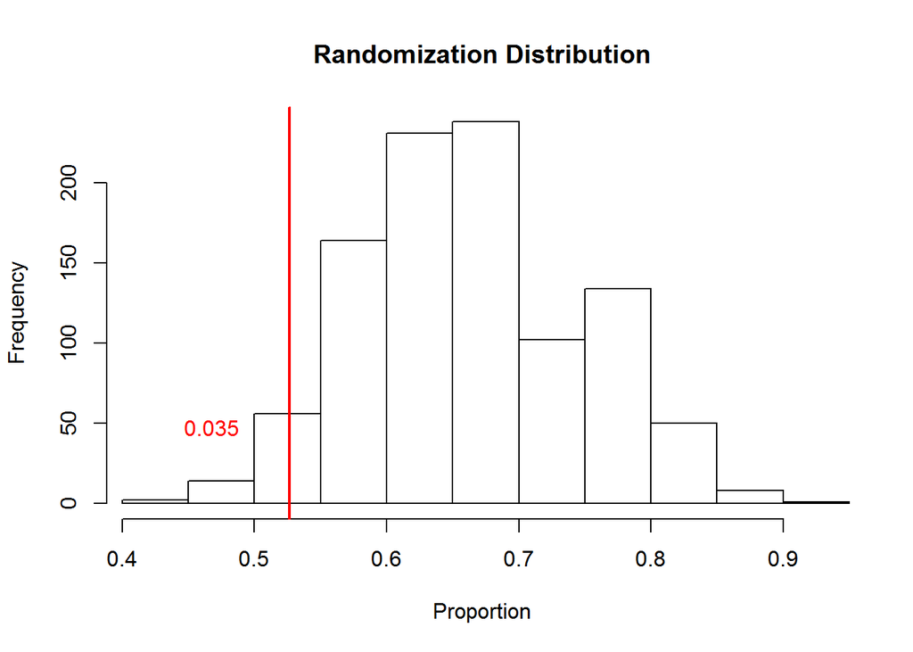

```
## SE =  0.079
## Smaller Tail Probability:  0.035
```

[output not shown]

[output cut: 152 more lines]

35/1000 simulations yielded a proportion (0.035) less than p-hat (0.53).

Some concerns I have about the data regard how it came about. Were the subjects polled, or was there a blind taste test? Also, since Coke is so popular, could there be a factor that is causal for its popularity, or since Pepsi is less popular could there be a factor causal for its lower popularity compared to Coke?

#### True Love?

Do BHSEC college students’ parents have a similar or different age of New York’s average age at first marriage?

```r
mean(marriage)
```

```
## [1] 27.34211
```

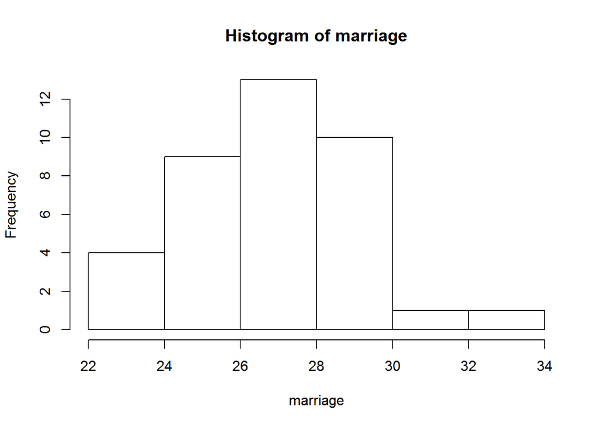

```r
hist(marriage)
```

Null hypothesis: The average first marriage age of BHSEC college students reflect that of New York State. $H_o: \mu = 29$

Alternative hypothesis: The average first marriage age of BHSEC college students is less than taht of New York State. $H_a: \mu < 29$

```r
fakeMarriage <- marriage + 1.65789
marriageSimulation<-sample(fakeMarriage, 38, replace = T)
mean(marriageSimulation)
```

```
## [1] 28.65789
```

```r
set.seed(789)
randomization.test(marriage, null = 29, num = 1000)
```

```
## One quantitative variable
## Observed Mean: 27.342
## Randomizing, please wait...
```

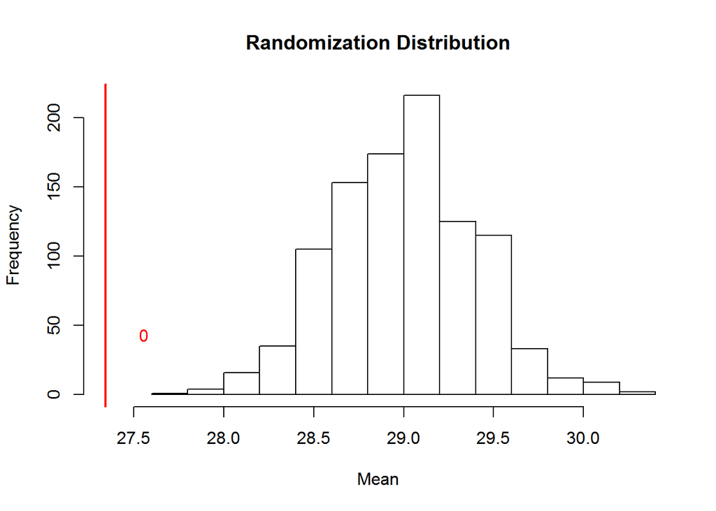

```
## SE =  0.395
## Smaller Tail Probability:  0
```

0/1000 simulations yielded a mean the same as the real sample or further away from the null.

#### BHSEC Lefties

Are BHSEC college students more likely to be left-handed than the general population?

```r
table(handedness)
```

```
## handedness
##  Left Right
##     5    33
```

```r
5/38
```

```
## [1] 0.1315789
```

$\hat{p} = 0.13$

Null hypothesis: The proportion of left-handed, BHSEC students reflect the proportion of left-handed people in the general population. $H_o: p = 0.10$

Alternative hypothesis: The proportion of left-handed, BHSEC students are is higher than that of the general population. $H_a: p > 0.10$

```r
handednessSimulation <- sample(11, 38, replace = T)
table(handednessSimulation)
```

```
## handednessSimulation
##  1  2  3  4  5  6  7  8  9 10 11
##  3  3  6  3  2  5  5  5  3  1  2
```

3/38 students were left handed in the simulation.

```r
set.seed(360)
randomization.test(handedness, null=(10/100), num = 1000, distribution = T)
```

```
## One categorical variable
## Observed Proportion: 0.132
## Randomizing, please wait...
```

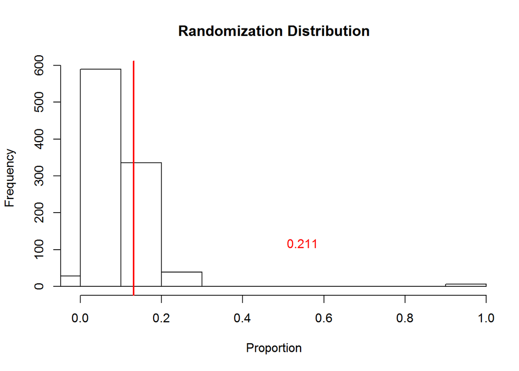

```
## SE =  0.089
## Smaller Tail Probability:  0.211
```

[output not shown]

[output cut: 185 more lines]

211/1000 simulations yielded a proportion (0.21) above 0.13.

Since p (0.21) is greater than 5% we do not reject the null and can conclude that the proportion of left-handed, BHSEC students is predicted to be reflective of the proportion of left-handed people in the general population.